# CPLN675_HW3_CGYEDM

#### ROC Curve

The area under our model’s ROC curve is 0.9185 – suggesting that our model is high quality! But with the information from the Confusion Matrix & Graph, it is high quality at predicting the majority of our data – which is not hazard zones. Lets get a map to truly understand the locational issues

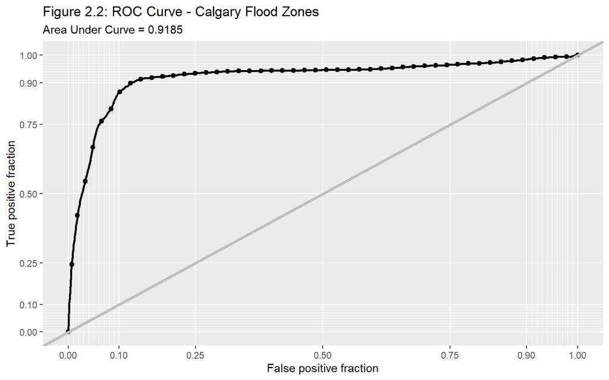

```r
#library(rROC)

library(plotROC)

ggplot() +
  geom_roc(
    data = focus.ROC,
    aes(d = labels, m = predictions),
    n.cuts = 50, labels = FALSE, colour = "#000000") +
  # geom_roc(
  #   data = test.predict,
  #   aes(d = as.numeric(test.predict$outcome), m = predict.2),
  #   n.cuts = 50, labels = FALSE, colour = "#FE9900") +
  style_roc(theme = theme_grey) +
  geom_abline(slope = 1, intercept = 0, size = 1.5, color = 'grey') +
  labs(
    title = "Figure 2.2: ROC Curve - Calgary Flood Zones",
    subtitle = glue("Area Under Curve = {AUC}")
    )
```

#### Confusion Map

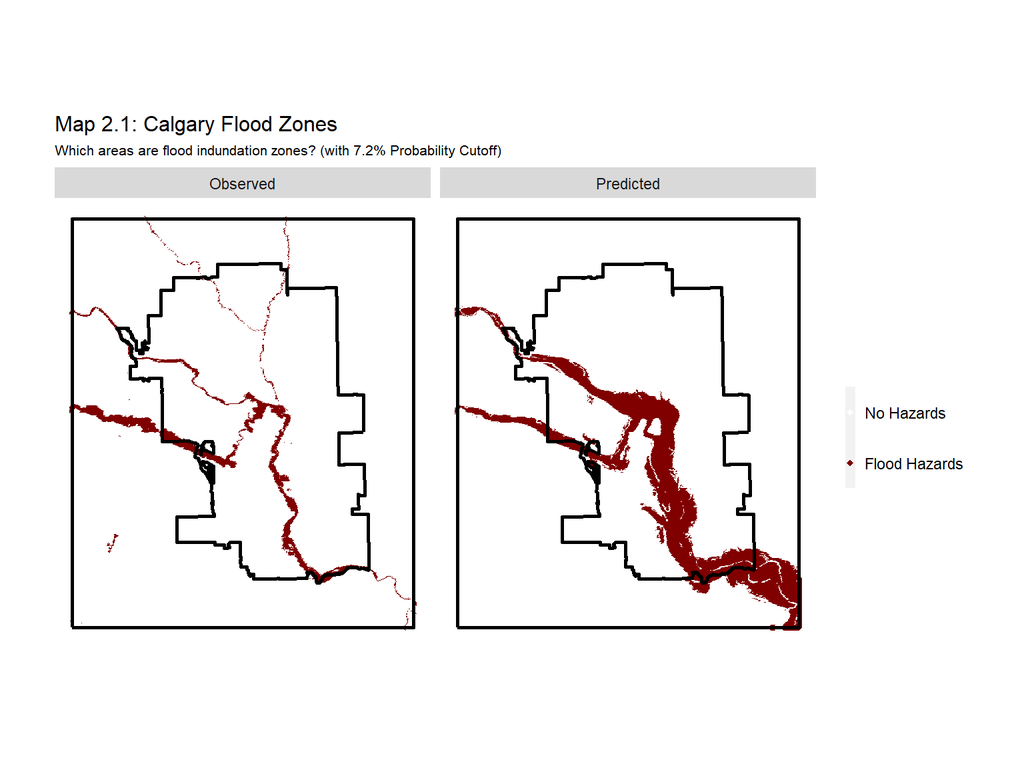

```r
cgy.fish %>%
  dplyr::select(flood, flood.predict) %>%
  transmute(
    `Observed` = flood,
    `Predicted` = flood.predict
  ) %>%
  gather(Variable, Value, -geometry) %>%
  ggplot(
    data=.,
   aes(x=xyC(.data[['geometry']])[,1], y=xyC(.data[['geometry']])[,2],
       colour=Value %>% as.factor())
    ) +
    geom_point(shape=18) +
    facet_wrap(~Variable) +
    scale_colour_manual(values = c('#FFFFFF','#800000'), labels=c("No Hazards","Flood Hazards"),
                        name="") +
  geom_cgy_bound() +
  geom_cgy_bbox() +
    labs(title="Map 2.1: Calgary Flood Zones", subtitle="Which areas are flood indundation zones? (with 7.2% Probability Cutoff)") +
    mapTheme
```

Excuses aside, Map 2.2 highlights the results in a map. It highlights that the areas near rivers are over estimated as flood zones. There is likely a feature missing that stresses a difference between floodable area near the river. Maybe adding concrete or asphalt variables could help.

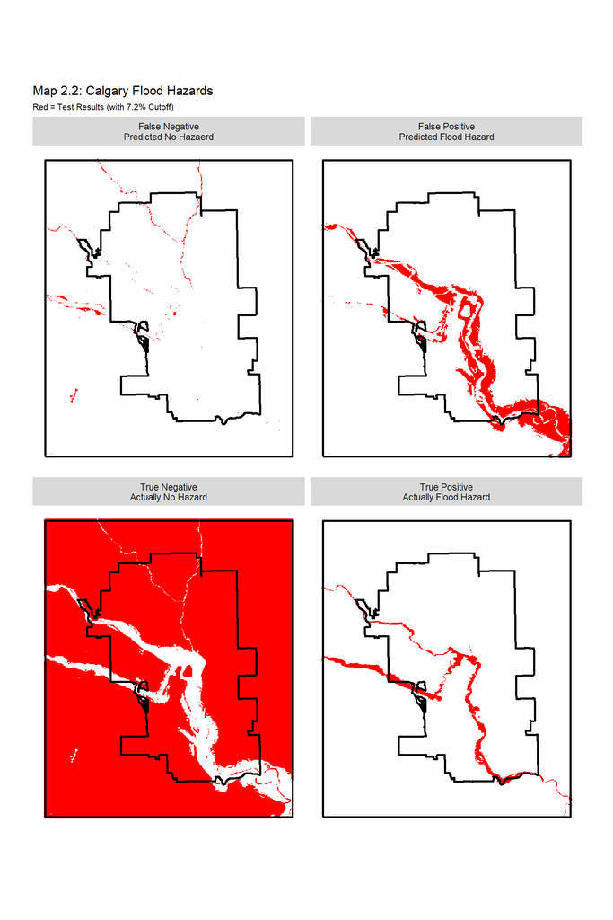

```r
ConfusionMatrix.metrics <-
  cgy.fish %>%
    mutate(flood.True.Pos = ifelse(flood  == 1 & flood.predict == 1, 1,0),
           flood.True.Neg = ifelse(flood  == 0 & flood.predict == 0, 1,0),
           flood.False.Pos = ifelse(flood  == 0 & flood.predict == 1, 1,0),
           flood.False.Neg = ifelse(flood  == 1 & flood.predict == 0, 1,0)
           ) %>%
    dplyr::select(.,
                  c('flood.True.Pos', 'flood.True.Neg', 'flood.False.Pos', 'flood.False.Neg')) %>%
  transmute(
    `True Negative\nActually No Hazard` = flood.True.Neg,
    `False Positive\nPredicted Flood Hazard` = flood.False.Pos,
    `False Negative\nPredicted No Hazaerd` = flood.False.Neg,
    `True Positive\nActually Flood Hazard` = flood.True.Pos
  ) %>%
  gather(Variable, Value, -geometry)

ggplot(data=ConfusionMatrix.metrics) +
  geom_point(aes(x=xyC(ConfusionMatrix.metrics)[,1],
                 y=xyC(ConfusionMatrix.metrics)[,2], colour = as.factor(Value))) +
  facet_wrap(~Variable) +
  scale_colour_manual(values = c('#FFFFFF', '#FF0000'),
                      labels=c("No Hazards","Flood Hazards"),
                        name="") +
  geom_cgy_bound() +
  geom_cgy_bbox() +
  labs(title="Map 2.2: Calgary Flood Hazards",
       subtitle="Red = Test Results (with 7.2% Cutoff)") +
  mapTheme +
  theme(legend.position = "none")
```

Although the Roc Curve suggested a high area under the curve, the other results charts suggest the model performs too much overestimation.

# 6. Conclusions

Overall the earlier visualizations show that Calgary has a physical and urban geography that is vulnerable to flooding. Although Edmonton has some shared features (e.g. rivers), it doesn’t have to worry about flooding as much.

Calgary’s history and vulnerability means that the city has to focus on understanding and mitigating the flooding. Even a local activist group is calling for a [Comprehensive Flood Mitigation Strategy] (http://protectcalgary.com/need-comprehensive-flood-mitigation-strategy-protect-economic-engine-canada-calgary-alberta/). To be fair, Calgary has already been active against another big flood by raising the reservoir walls, creating an early flood warning system, and developing upstream storage [[source](https://www.cbc.ca/news/canada/calgary/calgary-flood-mitigation-projects-four-year-anniversary-1.4162398)].

The prediction model created in this project could help understand which areas could be hazardous to flooding, but aren’t labeled as hazard zones.